# Prediction of Exercise Execution

**Human Activity Recognition, Weight Lifting Exercise Dataset**

**Chris Sweeney, November 18, 2014**

In contrast to studies to determine what activity a person is doing, this study evaluates participants execution of common weight lifting exercise, 4 done with incorrect form and one done per specification. This is identified as the classe, with “A”" being correct form and B through E being incorrect form mimicing common mistakes. Data were collected via sensors at the bicep, wrist and hips of the participants.

**Load Libraries**

```r
#load libraries
library(caret)
library(randomForest)
```

```r
library(corrplot)
```

**Load Data**

```r
train <- read.csv("pml-training.csv", na.strings=c("", "\"\"", "NA"))
test <- read.csv("pml-testing.csv", na.strings=c("", "\"\"", "NA"))
```

**First Look at the data**

There are 19622 obs. of 160 variables, but there are numerous columns that are entirely NA

```r
q<-sapply(train, function(x)all(!is.na(x)))
summary(q)
```

```
##    Mode   FALSE    TRUE    NA's
## logical     100      60       0
```

```r
##alternately caret::nearZeroVar(train)
```

**Clean Data**

We will remove the NA columns from the train and test datasets, additionally, we will remove several factor variables.

```r
cleanTrain <- train[, colSums(!is.na(test)) != 0]
cleanTest <- test[, colSums(!is.na(test)) != 0]
cleanTrain <- subset (cleanTrain,select = -c(X,user_name,cvtd_timestamp, raw_timestamp_part_1, raw_timestamp_part_2, new_window, num_window))
cleanTest <-  subset (cleanTest,select = -c(X,user_name, cvtd_timestamp, raw_timestamp_part_1, raw_timestamp_part_2, new_window, num_window))
```

This leaves 19622 obs. of 53 variables, the last variable in the train dataset being the classe variable we are modeling a predction for.

**Exploratory Data Analysis**

A quick review of the distribution of the classe variable. Also, a plot of correlations to help in starting to identify variables of importance to the model. (the corrplot is poorly rendered in the HTML, but I included the code if someone wants to run in R Studio)

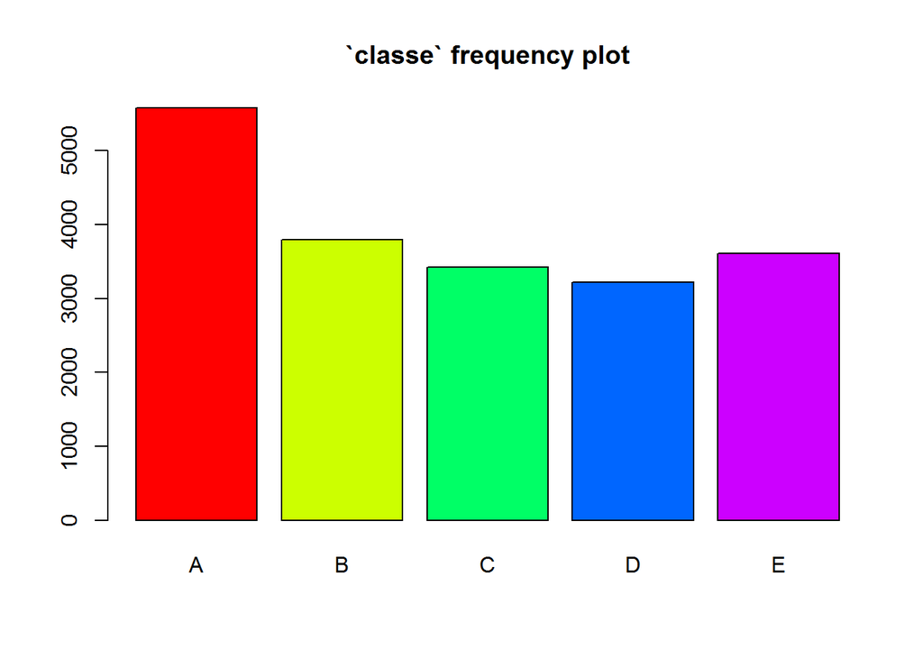

```r
plot(cleanTrain$classe,col=rainbow(5),main = "`classe` frequency plot")
```

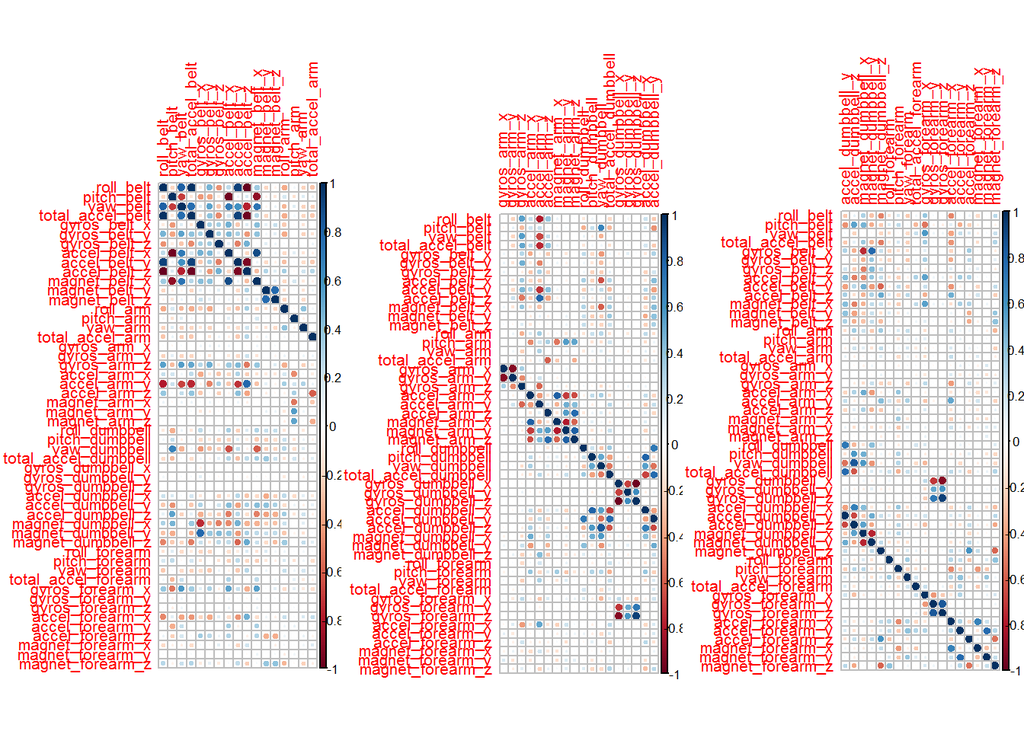

```r
m <-cor(cleanTrain[,-53])
#corrplot(m)
par(mfrow=c(1,3))
corrplot(m[,1:17])
corrplot(m[,18:35])
corrplot(m[,35:52])
```

**Partion Training Data**

Splitting the cleaned train dataset into a 70% training and 30% validation subset.

```r
set.seed=(4567)
partition <- createDataPartition(y = cleanTrain$classe, p = 0.7, list = FALSE)
trainingdata <- cleanTrain[partition, ]
validationdata  <- cleanTrain[-partition,]
```

**Create model from training data**

Using Random Forest in the caret package to model the training dataset.

```r
model <- train(classe ~ ., data = trainingdata, method = "rf", prox = TRUE,trControl = trainControl(method = "cv", number = 4, allowParallel = TRUE))
```

**Analysis**

A review of the variable importance in the model

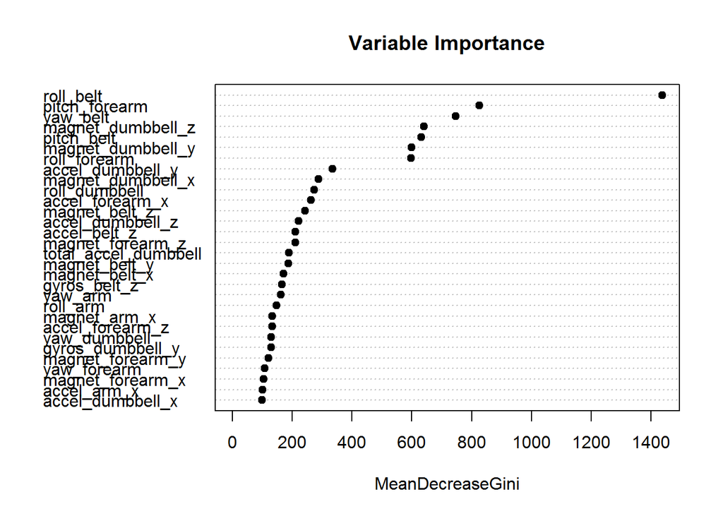

```r
varImpPlot(model$finalModel,sort = TRUE, pch=19, main="Variable Importance")
```

**Validate Model**

Validating the model against the subsetted validation dataset.

```r
test_predict <- predict(model,validationdata)
confusionMatrix(test_predict,validationdata$classe)
```

```
## Confusion Matrix and Statistics
##
##           Reference
## Prediction    A    B    C    D    E
##          A 1671    9    0    0    0
##          B    3 1129    4    0    0
##          C    0    1 1020    9    0
##          D    0    0    2  955    1
##          E    0    0    0    0 1081
##
## Overall Statistics
##
##                Accuracy : 0.995
##                  95% CI : (0.993, 0.997)
##     No Information Rate : 0.284
##     P-Value [Acc > NIR] : <2e-16
##
##                   Kappa : 0.994
##  Mcnemar's Test P-Value : NA
##
## Statistics by Class:
##
##                      Class: A Class: B Class: C Class: D Class: E
## Sensitivity             0.998    0.991    0.994    0.991    0.999
## Specificity             0.998    0.999    0.998    0.999    1.000
## Pos Pred Value          0.995    0.994    0.990    0.997    1.000
## Neg Pred Value          0.999    0.998    0.999    0.998    1.000
## Prevalence              0.284    0.194    0.174    0.164    0.184
## Detection Rate          0.284    0.192    0.173    0.162    0.184
## Detection Prevalence    0.285    0.193    0.175    0.163    0.184
## Balanced Accuracy       0.998    0.995    0.996    0.995    1.000
```

**Predict Classe in Test Data**

Running the model against the test dataset.

```r
answers <-predict(model,cleanTest)
answers <- as.character(answers)
answers
```

```
##  [1] "B" "A" "B" "A" "A" "E" "D" "B" "A" "A" "B" "C" "B" "A" "E" "E" "A"
## [18] "B" "B" "B"
```

**Data Citation**

Velloso, E.; Bulling, A.; Gellersen, H.; Ugulino, W.; Fuks, H. Qualitative Activity Recognition of Weight Lifting Exercises. Proceedings of 4th International Conference in Cooperation with SIGCHI (Augmented Human ’13) . Stuttgart, Germany: ACM SIGCHI, 2013.

**Link to Data**

http://groupware.les.inf.puc-rio.br/static/WLE/WearableComputing_weight_lifting_exercises_biceps_curl_variations.csv

Chris Sweeney, November 18, 2014